# Intro to Data Science - HW 6

## Step 4: Explore how the data changes over time

10. These data were collected in a period of several decades (1980-2013). You can thus observe changes over time with the help of a line chart. Create a **line chart**, with **year** on the X-axis and **new_sp_m014** on the Y-axis.

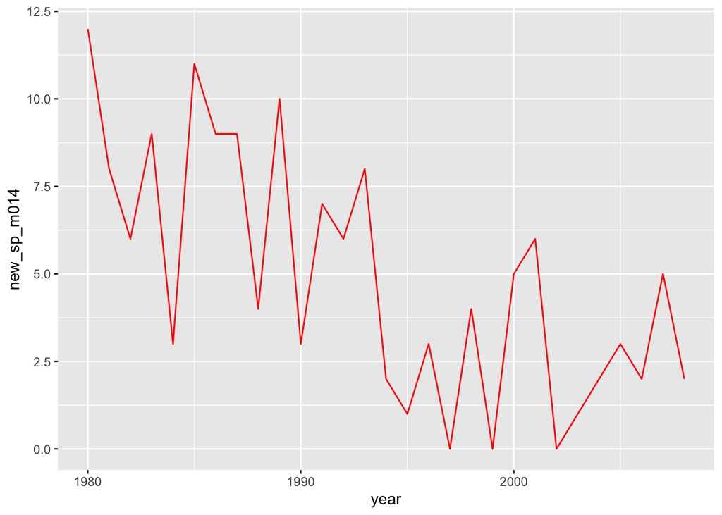

```r
ggplot(tbCan) + geom_line(aes(x=year, y=new_sp_m014), colour='red')
```

11. Next, create similar graphs for each of the other three variables. Change the **color** of the line plots (any color you want).

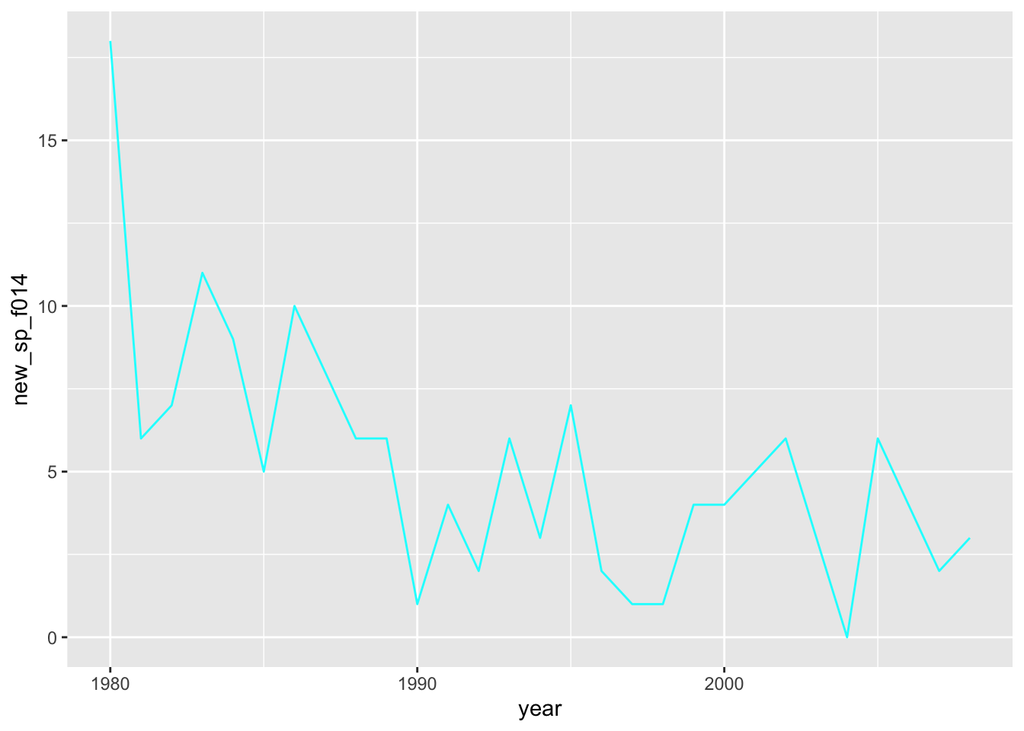

```r
ggplot(tbCan) + geom_line(aes(x=year, y=new_sp_f014), colour='cyan')
```

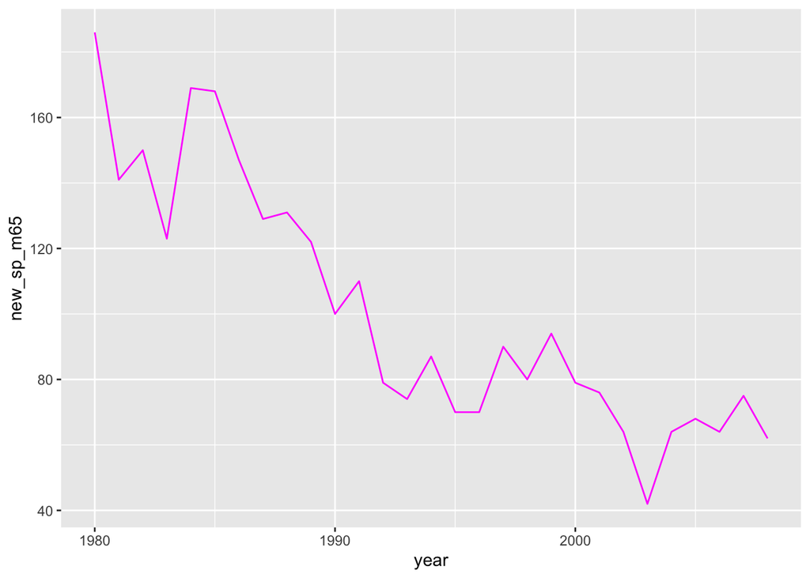

```r
ggplot(tbCan) + geom_line(aes(x=year, y=new_sp_m65), colour='magenta')
```